# Homework 10: PCA PCR PLS

DATA 627 - Statistical Machine Learning, Fall 2025

Author

Ana Paula Miranda

Published

October 25, 2025

# 1 College Applications Continued

This continues the College data problem from the previous h/w. (Chap. 6, # 9 cd, p.286-287)

Predict the number of applications received based on the other variables in the College data set from {ISLR2}.

````markdown
```{r}
#| message: false
#| include: true
library(tidyverse)
library(ISLR2)
library(pls)
glimpse(College)
```
````

```
Rows: 777
Columns: 18
$ Private     <fct> Yes, Yes, Yes, Yes, Yes, Yes, Yes, Yes, Yes, Yes, Yes, Yes…
$ Apps        <dbl> 1660, 2186, 1428, 417, 193, 587, 353, 1899, 1038, 582, 173…
$ Accept      <dbl> 1232, 1924, 1097, 349, 146, 479, 340, 1720, 839, 498, 1425…
$ Enroll      <dbl> 721, 512, 336, 137, 55, 158, 103, 489, 227, 172, 472, 484,…
$ Top10perc   <dbl> 23, 16, 22, 60, 16, 38, 17, 37, 30, 21, 37, 44, 38, 44, 23…
$ Top25perc   <dbl> 52, 29, 50, 89, 44, 62, 45, 68, 63, 44, 75, 77, 64, 73, 46…
$ F.Undergrad <dbl> 2885, 2683, 1036, 510, 249, 678, 416, 1594, 973, 799, 1830…
$ P.Undergrad <dbl> 537, 1227, 99, 63, 869, 41, 230, 32, 306, 78, 110, 44, 638…
$ Outstate    <dbl> 7440, 12280, 11250, 12960, 7560, 13500, 13290, 13868, 1559…
$ Room.Board  <dbl> 3300, 6450, 3750, 5450, 4120, 3335, 5720, 4826, 4400, 3380…
$ Books       <dbl> 450, 750, 400, 450, 800, 500, 500, 450, 300, 660, 500, 400…
$ Personal    <dbl> 2200, 1500, 1165, 875, 1500, 675, 1500, 850, 500, 1800, 60…
$ PhD         <dbl> 70, 29, 53, 92, 76, 67, 90, 89, 79, 40, 82, 73, 60, 79, 36…
$ Terminal    <dbl> 78, 30, 66, 97, 72, 73, 93, 100, 84, 41, 88, 91, 84, 87, 6…
$ S.F.Ratio   <dbl> 18.1, 12.2, 12.9, 7.7, 11.9, 9.4, 11.5, 13.7, 11.3, 11.5, …
$ perc.alumni <dbl> 12, 16, 30, 37, 2, 11, 26, 37, 23, 15, 31, 41, 21, 32, 26,…
$ Expend      <dbl> 7041, 10527, 8735, 19016, 10922, 9727, 8861, 11487, 11644,…
$ Grad.Rate   <dbl> 60, 56, 54, 59, 15, 55, 63, 73, 80, 52, 73, 76, 74, 68, 55…
```

Previous results for predicting the number of college applications, using a 50% split validation set and seed 123, include:

| Method | Prediction MSE | Predictors |
| --- | --- | --- |
| Stepwise Least Squares (validation) | 1,327,026 | 12 |
| Stepwise Least Squares (K=10-fold) | 1,264,962 | 12 |
| Ridge Regression (lambda.min) | 2,092,402 | 17 |
| Lasso (lambda.1se) | 1,528,732 | 4 |
| Lasso (lambda.min) | 1,391,186 | 12 |

Now fit models using two additional regularization methods and evaluate performance using the validation set based on 50% split so we remain consistent with previous work. Use `set.seed(123)` where appropriate:

(a) PCR model. Choose $M$, the number of principal components, using cross-validation.

```r
n <- nrow(College)
set.seed(123)
Z <- sample(1:n, n/2)

train_data <- College[Z,]
test_data <- College[-Z,]
```

```r
set.seed(123)
pcrv_fit <- pcr(Apps ~ ., data = train_data, scale = TRUE, validation = "CV")
summary(pcrv_fit)
```

```
Data:   X dimension: 388 17
    Y dimension: 388 1
Fit method: svdpc
Number of components considered: 17

VALIDATION: RMSEP
Cross-validated using 10 random segments.
       (Intercept)  1 comps  2 comps  3 comps  4 comps  5 comps  6 comps
CV            3258     3221     1664     1619     1329     1321     1221
adjCV         3258     3222     1663     1617     1317     1317     1218
       7 comps  8 comps  9 comps  10 comps  11 comps  12 comps  13 comps
CV        1217     1219     1153      1152      1153      1156      1161
adjCV     1218     1221     1150      1150      1150      1153      1158
       14 comps  15 comps  16 comps  17 comps
CV         1164      1160      1027      1024
adjCV      1161      1160      1022      1020

TRAINING: % variance explained
      1 comps  2 comps  3 comps  4 comps  5 comps  6 comps  7 comps  8 comps
X      32.969    59.69    66.68    72.25    77.31    81.82    85.18    88.34
Apps    3.259    74.43    76.35    84.40    84.42    86.69    86.79    87.01
      9 comps  10 comps  11 comps  12 comps  13 comps  14 comps  15 comps
X       91.32     93.61     95.48     97.05     98.11     98.90     99.40
Apps    88.38     88.39     88.47     88.49     88.50     88.51     88.74
      16 comps  17 comps
X        99.81    100.00
Apps     91.48     91.58
```

```r
opt_M <- which.min(pcrv_fit$validation$PRESS)
opt_M
```

```
[1] 17
```

```r
pcr_pred <- predict(pcrv_fit, test_data, ncomp = opt_M)
test_MSE <- mean((pcr_pred - test_data$Apps)^2)
test_MSE
```

```
[1] 1373995
```

- The number of components considered was 17.
- The best number of components that minimizes cross validation prediction error is $M = 17$.
- We can see that CP17 explains about 91.58% of the variation in `Apps` as it also provides the smallest value for adjCV RMSEP = 1020.
- This means that PCR model with 17 principal components provides de best prediction MSE, which is equal to 1.373.995.

(b) PLS model. Choose $M$, the number of principal components, using cross-validation.

```r
set.seed(123)
plsrv_fit <- plsr(Apps ~ ., data = train_data, scale = TRUE, validation = "CV")
summary(plsrv_fit)
```

```
Data:   X dimension: 388 17
    Y dimension: 388 1
Fit method: kernelpls
Number of components considered: 17

VALIDATION: RMSEP
Cross-validated using 10 random segments.
       (Intercept)  1 comps  2 comps  3 comps  4 comps  5 comps  6 comps
CV            3258     1502     1260     1137     1105     1070     1039
adjCV         3258     1501     1260     1135     1102     1067     1033
       7 comps  8 comps  9 comps  10 comps  11 comps  12 comps  13 comps
CV        1033     1026     1025      1023      1024      1025      1025
adjCV     1028     1021     1021      1019      1019      1020      1020
       14 comps  15 comps  16 comps  17 comps
CV         1025      1025      1024      1024
adjCV      1020      1020      1020      1020

TRAINING: % variance explained
      1 comps  2 comps  3 comps  4 comps  5 comps  6 comps  7 comps  8 comps
X       26.97    43.83    65.16    69.79    73.63    76.18    79.97    81.98
Apps    79.33    85.98    88.76    89.67    90.59    91.43    91.54    91.56
      9 comps  10 comps  11 comps  12 comps  13 comps  14 comps  15 comps
X       84.18     86.85     90.18     91.77     93.55     95.40     97.35
Apps    91.57     91.57     91.57     91.58     91.58     91.58     91.58
      16 comps  17 comps
X        99.06    100.00
Apps     91.58     91.58
```

```r
opt_M <- which.min(plsrv_fit$validation$PRESS)
opt_M
```

```
[1] 10
```

```r
plsr_pred <- predict(plsrv_fit, test_data, ncomp = opt_M)
test_MSE <- mean((plsr_pred - test_data$Apps)^2)
test_MSE
```

```
[1] 1384151
```

- The number of components considered was 17 as well.
- The best number of components that minimizes cross validation prediction error is $M = 10$.
- We can see that CP10 explains about 91.57% of the variation in `Apps` as it also provides the smallest value for adjCV RMSEP = 1019.
- This means that PSL model with 10 principal components provides de best prediction MSE, which is equal to 1.384.151.

(c) Evaluate performance of each method in terms of **prediction MSE** and number of components. Show the validation plots for both models.

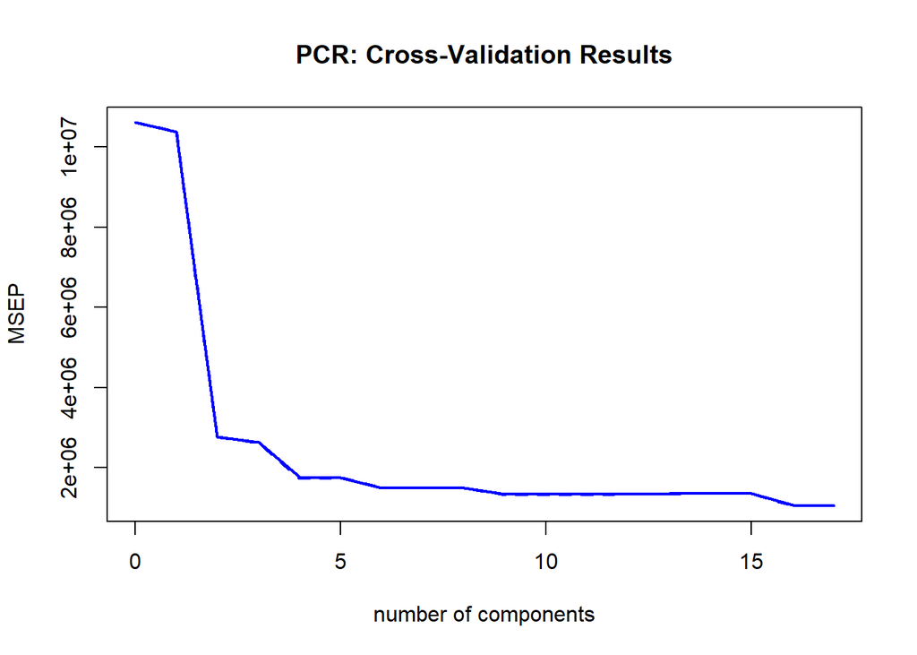

```r
validationplot(pcrv_fit, val.type = "MSEP",
               main = "PCR: Cross-Validation Results",
               col = "blue", lwd = 2, )
```

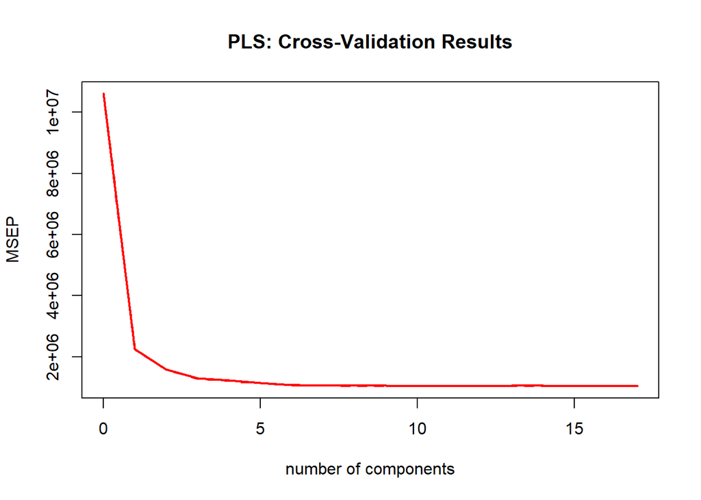

```r
validationplot(plsrv_fit, val.type = "MSEP",
               main = "PLS: Cross-Validation Results",
                col = "red", lwd = 2)
```

- PCR plot: MSE decreases quickly for the first few components, then levels off and the optimal $M$ is reached at the end around 16 - 17.
- PLS plot: MSE decreases quickly for the first few components, then stabilizes sooner and the optimal $M$ is reached around 7 - 10.

In conclusion, PLS tends to achieve comparable predictive performance (as in this case), or sometimes even better, using fewer components in the model.

(d) Add the results into the summary table. Comment on the results obtained including MSE Prediction and number of predictors.

- Recommend a method and provide a rationale?
- Hint: Consider help for: `pls::validationplot()`, `pls::R2()`, `pls::MSEP()`

| Method | Prediction MSE | Predictors |
| --- | --- | --- |
| Stepwise Least Squares (validation) | 1,327,026 | 12 |
| Stepwise Least Squares (K=10-fold) | 1,264,962 | 12 |
| Ridge Regression (lambda.min) | 2,092,402 | 17 |
| Lasso (lambda.1se) | 1,528,732 | 4 |
| Lasso (lambda.min) | 1,391,186 | 12 |
| **PCR** | **1.373.995** | **17** |
| **PLS** | **1.384.151** | **10** |

# 2 Comparison of dimension reduction methods

We want to predict median value of owner-occupied homes, `medv`, in the Boston data set in the {ISLR2} package. It should have 13 variables. Leave `rad` as an integer.

```r
library(tidyverse)
library(ISLR2)
library(boot)
library(leaps)
library(glmnet)
library(pls)
glimpse(Boston)
```

```
Rows: 506
Columns: 13
$ crim    <dbl> 0.00632, 0.02731, 0.02729, 0.03237, 0.06905, 0.02985, 0.08829,…
$ zn      <dbl> 18.0, 0.0, 0.0, 0.0, 0.0, 0.0, 12.5, 12.5, 12.5, 12.5, 12.5, 1…
$ indus   <dbl> 2.31, 7.07, 7.07, 2.18, 2.18, 2.18, 7.87, 7.87, 7.87, 7.87, 7.…
$ chas    <int> 0, 0, 0, 0, 0, 0, 0, 0, 0, 0, 0, 0, 0, 0, 0, 0, 0, 0, 0, 0, 0,…
$ nox     <dbl> 0.538, 0.469, 0.469, 0.458, 0.458, 0.458, 0.524, 0.524, 0.524,…
$ rm      <dbl> 6.575, 6.421, 7.185, 6.998, 7.147, 6.430, 6.012, 6.172, 5.631,…
$ age     <dbl> 65.2, 78.9, 61.1, 45.8, 54.2, 58.7, 66.6, 96.1, 100.0, 85.9, 9…
$ dis     <dbl> 4.0900, 4.9671, 4.9671, 6.0622, 6.0622, 6.0622, 5.5605, 5.9505…
$ rad     <int> 1, 2, 2, 3, 3, 3, 5, 5, 5, 5, 5, 5, 5, 4, 4, 4, 4, 4, 4, 4, 4,…
$ tax     <dbl> 296, 242, 242, 222, 222, 222, 311, 311, 311, 311, 311, 311, 31…
$ ptratio <dbl> 15.3, 17.8, 17.8, 18.7, 18.7, 18.7, 15.2, 15.2, 15.2, 15.2, 15…
$ lstat   <dbl> 4.98, 9.14, 4.03, 2.94, 5.33, 5.21, 12.43, 19.15, 29.93, 17.10…
$ medv    <dbl> 24.0, 21.6, 34.7, 33.4, 36.2, 28.7, 22.9, 27.1, 16.5, 18.9, 15…
```

1. Use four regularization methods, lasso, ridge regression, PCR, and PLS. Recommend a model Provide a rationale based on their predictive performance (Mean Squared Error) and the number of predictors.
- Use `set.seed(1234)` whenever appropriate.
- **Do not use a validation set.** Use k=10 fold cross-validation for all models.

```r
reg <- lm(medv ~ ., data = Boston)
x <- model.matrix(reg)[, -1]
dim(x)
```

```
[1] 506  12
```

- a.1 Ridge Regression

```r
set.seed(1234)
rr_cv <- cv.glmnet(x, y = Boston$medv, alpha = 0)
rr_cv
```

```
Call:  cv.glmnet(x = x, y = Boston$medv, alpha = 0)

Measure: Mean-Squared Error

    Lambda Index Measure    SE Nonzero
min  0.678   100   24.54 3.063      12
1se  3.970    81   27.51 2.991      12
```

```r
rr_pred <- predict(rr_cv, newx = x, s = "lambda.min")
mean((rr_pred - Boston$medv)^2) |> round(3)
```

```
[1] 22.959
```

```r
rr_pred <- predict(rr_cv, newx = x, s = "lambda.1se")
mean((rr_pred - Boston$medv)^2) |> round(3)
```

```
[1] 26.434
```

```r
set.seed(1234)
lr_cv <- cv.glmnet(x, y = Boston$medv, alpha = 1)
lr_cv
```

```
Call:  cv.glmnet(x = x, y = Boston$medv, alpha = 1)

Measure: Mean-Squared Error

    Lambda Index Measure    SE Nonzero
min 0.0307    59   24.22 3.005      10
1se 0.3789    32   27.01 3.120       8
```

```r
lr_pred <- predict(lr_cv, newx = x, s = "lambda.min")
mean((lr_pred - Boston$medv)^2) |> round(3)
```

```
[1] 22.478
```

```r
lr_pred2 <- predict(lr_cv, newx = x, s = "lambda.1se")
mean((lr_pred2 - Boston$medv)^2) |> round(3)
```

```
[1] 25.376
```

- The best lambda value that minimizes the CV MSE was $\lambda (min) = 0.0307$ and $\lambda (1se) = 0.3789$. For the minimum MSE there are 10 parameters in the model. However, for `1se` MSE, LASSO method shrunk 4 parameters to zero and there are now 8 parameters in the model.
- a.3 PC Regression

```r
set.seed(1234)
pcr_medv_fit <- pcr(medv ~ ., data = Boston,
                    scale = TRUE,
                    validation = "CV")
summary(pcr_medv_fit)
```

```
Data:   X dimension: 506 12
    Y dimension: 506 1
Fit method: svdpc
Number of components considered: 12

VALIDATION: RMSEP
Cross-validated using 10 random segments.
       (Intercept)  1 comps  2 comps  3 comps  4 comps  5 comps  6 comps
CV           9.206    7.310    6.530    5.541    5.348    5.183    5.196
adjCV        9.206    7.309    6.531    5.538    5.333    5.177    5.191
       7 comps  8 comps  9 comps  10 comps  11 comps  12 comps
CV       5.175    5.181    5.157     5.139     4.984     4.907
adjCV    5.170    5.176    5.152     5.138     4.975     4.898

TRAINING: % variance explained
      1 comps  2 comps  3 comps  4 comps  5 comps  6 comps  7 comps  8 comps
X       49.23    60.89    70.73    77.85    84.54    89.01    92.31    94.62
medv    36.96    50.50    64.15    67.32    69.04    69.06    69.58    69.61
      9 comps  10 comps  11 comps  12 comps
X       96.50     98.05     99.47    100.00
medv    70.17     70.53     72.59     73.43
```

```r
opt_M_medv_pcr <- which.min(pcr_medv_fit$validation$PRESS)
opt_M_medv_pcr
```

```
[1] 12
```

```r
pcr_medv_pred <- predict(pcr_medv_fit, Boston, ncomp = opt_M_medv_pcr)
MSE_medv_pcr <- mean((pcr_medv_pred - Boston$medv)^2)
MSE_medv_pcr
```

```
[1] 22.42968
```

- a.4 PLS Regression

```r
set.seed(1234)
pls_medv_fit <- plsr(medv ~ ., data = Boston,
                     scale = TRUE,
                     validation = "CV")
summary(pls_medv_fit)
```

```
Data:   X dimension: 506 12
    Y dimension: 506 1
Fit method: kernelpls
Number of components considered: 12

VALIDATION: RMSEP
Cross-validated using 10 random segments.
       (Intercept)  1 comps  2 comps  3 comps  4 comps  5 comps  6 comps
CV           9.206    6.547    5.131    5.045    4.974    4.939    4.921
adjCV        9.206    6.545    5.127    5.038    4.964    4.930    4.912
       7 comps  8 comps  9 comps  10 comps  11 comps  12 comps
CV       4.913    4.906    4.907     4.907     4.907     4.907
adjCV    4.904    4.897    4.898     4.898     4.898     4.898

TRAINING: % variance explained
      1 comps  2 comps  3 comps  4 comps  5 comps  6 comps  7 comps  8 comps
X       47.81    59.71    67.51    72.82    79.09    82.22    86.00    89.95
medv    49.84    69.90    71.58    72.75    73.15    73.30    73.38    73.42
      9 comps  10 comps  11 comps  12 comps
X       92.88     96.16     98.27    100.00
medv    73.43     73.43     73.43     73.43
```

```r
opt_M_medv_pls <- which.min(pls_medv_fit$validation$PRESS)
opt_M_medv_pls
```

```
[1] 8
```

```r
pls_medv_pred <- predict(pls_medv_fit, Boston, ncomp = opt_M_medv_pls)
MSE_medv_pls <- mean((pls_medv_pred - Boston$medv)^2)
MSE_medv_pls
```

```
[1] 22.43538
```

- a.5 Summary

| Method | Prediction MSE | Predictors |
| --- | --- | --- |
| Ridge Regression (lambda.min) | 22.959 | 12 |
| Lasso (lambda.min) | 22.478 | 10 |
| Lasso (lambda.1se) | 25.376 | 8 |
| PCR | 22.42968 | 12 PCs |
| PLSR | 22.43538 | 8 PCs |

- My recommendation: The Lasso model with Lambda min = 22.47 which is one of the lowest prediction MSE - indicating a good predictive performance. This is my choice because Lasso retains interpretability by keeping actual predictors in the model rather than abstract PCs. It uses 10 predictors, fewer than Ridge (12) and PCR (12 PCs), which means it achieves nearly the best accuracy with a simpler model. Therefore, it’s the one of the most efficient and interpretable choice for predicting median home values (medv) in the Boston dataset.
- The Lasso at `lambda.1se` uses only 8 predictors, but with a noticeably higher MSE (25.38), suggesting a loss in predictive power that doesn’t justify the extra simplicity.
- Comparison with PCR and PLSR: PCR (MSE = 22.43) and PLSR (MSE = 22.44) performed slightly better, but their predictors (principal components) are linear combinations of all variables, making interpretation less straightforward and that’s why I would go with Lasso.
2. Create a new data set with `rad` as a factor. Recompute the Lasso (lambda.1se) and PLSR results. Rename the variables so you can compare results.

```r
table(Boston$rad)
```

```
  1   2   3   4   5   6   7   8  24
 20  24  38 110 115  26  17  24 132
```

```r
Boston |>
  dplyr::mutate(rad = as.factor(rad)) ->
  Boston_rf
Xrf <- model.matrix(lm(medv ~ ., data = Boston_rf))[,-1]
dim(Xrf)
```

```
[1] 506  19
```

- b.1 Lasso with `rad` as a factor.

```r
set.seed(1234)
lr_cv_rf <- cv.glmnet(Xrf, y = Boston_rf$medv, alpha = 1)
lr_cv_rf
```

```
Call:  cv.glmnet(x = Xrf, y = Boston_rf$medv, alpha = 1)

Measure: Mean-Squared Error

    Lambda Index Measure    SE Nonzero
min 0.0233    62   24.00 2.958      17
1se 0.3789    32   26.84 3.157       9
```

```r
lr_pred_rf <- predict(lr_cv_rf, newx = Xrf, s = "lambda.min")
mean((lr_pred_rf - Boston_rf$medv)^2) |> round(3)
```

```
[1] 21.754
```

```r
lr_pred_rf2 <- predict(lr_cv_rf, newx = Xrf, s = "lambda.1se")
mean((lr_pred_rf2 - Boston_rf$medv)^2) |> round(3)
```

```
[1] 25.102
```

- b.2 Comment on the differences in the coefficients between the models with `rad` as a number and `rad` as a factor. For convenience you can use code similar to the following with the appropriate model names. (Commented so your can render the document before getting this far.)

```r
dplyr::bind_rows(
  coef(lr_cv) |> round(3) |> as.matrix() |> as.data.frame() |> tibble::rownames_to_column(),
  coef(lr_cv_rf) |> round(3) |> as.matrix() |> as.data.frame() |> tibble::rownames_to_column()
) |>
dplyr::mutate(model = c(rep("lasso", length(coef(lr_cv))), rep("lasso-rf", length(coef(lr_cv_rf))))) |>
  dplyr::arrange(rowname) |>
tidyr::pivot_wider(names_from = rowname, values_from = lambda.1se)
```

```
# A tibble: 2 × 22
  model `(Intercept)`   age  chas   crim    dis indus  lstat   nox ptratio   rad
  <chr>         <dbl> <dbl> <dbl>  <dbl>  <dbl> <dbl>  <dbl> <dbl>   <dbl> <dbl>
1 lasso          21.7     0  2.01 -0.036 -0.336     0 -0.536 -4.47  -0.794     0
2 lass…          21.4     0  1.99 -0.037 -0.333     0 -0.537 -3.87  -0.801    NA
# ℹ 11 more variables: rad2 <dbl>, rad24 <dbl>, rad3 <dbl>, rad4 <dbl>,
#   rad5 <dbl>, rad6 <dbl>, rad7 <dbl>, rad8 <dbl>, rm <dbl>, tax <dbl>,
#   zn <dbl>
```

```r
coef(lr_cv)
```

```
13 x 1 sparse Matrix of class "dgCMatrix"
               lambda.1se
(Intercept) 21.6930348935
crim        -0.0361211655
zn           .
indus        .
chas         2.0055671685
nox         -4.4684349952
rm           4.1551022132
age          .
dis         -0.3360490429
rad          .
tax         -0.0002155154
ptratio     -0.7942971898
lstat       -0.5358882567
```

```r
coef(lr_cv_rf)
```

```
20 x 1 sparse Matrix of class "dgCMatrix"
             lambda.1se
(Intercept) 21.40715389
crim        -0.03650426
zn           .
indus        .
chas         1.99201775
nox         -3.87307784
rm           4.14052153
age          .
dis         -0.33314470
rad2         .
rad3         1.18978660
rad4         .
rad5         .
rad6         .
rad7         .
rad8         0.12880428
rad24        .
tax          .
ptratio     -0.80139399
lstat       -0.53698633
```

- In the method with `rad` as integer, `rad` wasn’t even part of the model.
- In the method with `rad` as factor, `rad` levels 3 and 8 are kept in the model.
- b.3 PLSR with `rad` as a factor.

```r
set.seed(1234)
pls_medv_fit_rf <- plsr(medv ~ ., data = Boston_rf,
                        scale = TRUE,
                        validation = "CV")
summary(pls_medv_fit_rf)
```

```
Data:   X dimension: 506 19
    Y dimension: 506 1
Fit method: kernelpls
Number of components considered: 19

VALIDATION: RMSEP
Cross-validated using 10 random segments.
       (Intercept)  1 comps  2 comps  3 comps  4 comps  5 comps  6 comps
CV           9.206    6.485    5.258    5.049    4.985    4.924    4.919
adjCV        9.206    6.483    5.251    5.040    4.975    4.912    4.907
       7 comps  8 comps  9 comps  10 comps  11 comps  12 comps  13 comps
CV       4.901    4.883    4.881     4.874     4.873     4.871     4.870
adjCV    4.889    4.871    4.869     4.863     4.861     4.859     4.859
       14 comps  15 comps  16 comps  17 comps  18 comps  19 comps
CV        4.870     4.870     4.870     4.870     4.870     4.870
adjCV     4.858     4.859     4.859     4.859     4.859     4.859

TRAINING: % variance explained
      1 comps  2 comps  3 comps  4 comps  5 comps  6 comps  7 comps  8 comps
X       31.01    40.28    46.57    52.06    55.09    60.77    63.70    67.66
medv    50.98    68.78    71.82    72.88    73.78    73.93    74.07    74.15
      9 comps  10 comps  11 comps  12 comps  13 comps  14 comps  15 comps
X       69.90     73.40     76.79     79.37     83.66     87.81     89.49
medv    74.28     74.32     74.34     74.34     74.34     74.34     74.34
      16 comps  17 comps  18 comps  19 comps
X        93.11     96.36     98.76    100.00
medv     74.34     74.34     74.34     74.34
```

```r
opt_M_medv_pls_rf <- which.min(pls_medv_fit_rf$validation$PRESS)
opt_M_medv_pls_rf
```

```
[1] 14
```

```r
pls_medv_pred_rf <- predict(pls_medv_fit_rf, Boston_rf, ncomp = opt_M_medv_pls_rf)
MSE_pls_rf <- mean((pls_medv_pred_rf - Boston_rf$medv)^2)
MSE_pls_rf
```

```
[1] 21.65899
```

c. Compute both Lasso (lambda.1se) and PLSR **without `rad` in the model at all.**

- LASSO

```r
X_no_rad <- model.matrix(lm(medv ~ . -rad, data = Boston))[,-1]
dim(X_no_rad)
```

```
[1] 506  11
```

```r
set.seed(1234)
lr_cv_nr <- cv.glmnet(X_no_rad, y = Boston$medv, alpha = 1)
lr_cv_nr
```

```
Call:  cv.glmnet(x = X_no_rad, y = Boston$medv, alpha = 1)

Measure: Mean-Squared Error

    Lambda Index Measure    SE Nonzero
min 0.0446    55   25.08 3.167       9
1se 0.5009    29   28.00 3.045       8
```

```r
lr_pred_nr <- predict(lr_cv_nr, newx = X_no_rad, s = "lambda.min")
mean((lr_pred_nr - Boston$medv)^2) |> round(3)
```

```
[1] 23.315
```

```r
lr_pred_nr2 <- predict(lr_cv_nr, newx = X_no_rad, s = "lambda.1se")
mean((lr_pred_nr2 - Boston$medv)^2) |> round(3)
```

```
[1] 26.579
```

- PLSR

```r
set.seed(1234)
pls_medv_fit_nr <- plsr(medv ~ . -rad, data = Boston,
                        scale = TRUE,
                        validation = "CV")
summary(pls_medv_fit_nr)
```

```
Data:   X dimension: 506 11
    Y dimension: 506 1
Fit method: kernelpls
Number of components considered: 11

VALIDATION: RMSEP
Cross-validated using 10 random segments.
       (Intercept)  1 comps  2 comps  3 comps  4 comps  5 comps  6 comps
CV           9.206    6.407    5.139    5.060    5.006    5.000    4.997
adjCV        9.206    6.406    5.136    5.053    4.997    4.991    4.988
       7 comps  8 comps  9 comps  10 comps  11 comps
CV       4.996    4.996    4.996     4.995     4.995
adjCV    4.987    4.987    4.987     4.987     4.987

TRAINING: % variance explained
      1 comps  2 comps  3 comps  4 comps  5 comps  6 comps  7 comps  8 comps
X       47.00    60.28    67.84    71.48    78.03    82.40    87.67    91.76
medv    51.96    69.73    71.35    72.29    72.39    72.42    72.42    72.42
      9 comps  10 comps  11 comps
X       96.20     98.28    100.00
medv    72.42     72.42     72.42
```

```r
opt_M_medv_pls_nr <- which.min(pls_medv_fit_nr$validation$PRESS)
opt_M_medv_pls_nr
```

```
[1] 11
```

```r
pls_medv_pred_nr <- predict(pls_medv_fit_nr, Boston, ncomp = opt_M_medv_pls_nr)
MSE_pls_nr <- mean((pls_medv_pred_nr - Boston$medv)^2)
MSE_pls_nr
```

```
[1] 23.28088
```

d. Summarize the results from models in b and c in the table below. Recommend a model and provide your rationale.

[output not shown]